# (PSL) Project 3, CS598 PSL F24

Section 1.

From a database of 50k identification-tagged verbal movie reviews in text format, data is loaded from .csv files from 5 folds. Each fold includes true labels for the data in addition to the training and test data. In case any values were missing, NA values were dropped.

The tidytext package was used for cleaning as follows: used lowercase throughout, for consistency; remobed punctuation and numbers; removed common articles (e.g., “a”, “the”) and conjunctions (e.g., “and”, “or”, “but”); reduced words to stems where possible using wordStem() from SnowballC.

The features matrices X_train and X_test consisted of 1536 embedding dimensions; the target variable y_train and y_test consisted of either 0 for negative review or 1 for positive review.

Logistic regression using glmnet was used, with cross-validation (cv.glmnet()) to determine optimal lambda, and an attempt at parallel computation for speed-up (doParallel). The final model was trained on the best lambda (glmnet()).

AUC for split 1 : 0.9866996 AUC for split 2 : 0.9863151 AUC for split 3 : 0.9861288 AUC for split 4 : 0.9866757 AUC for split 5 : 0.9860347

AUC Results for each split: [1] 0.9866996 0.9863151 0.9861288 0.9866757 0.9860347

Total Execution Time: 22.39768 seconds

System Specifications: sysname “Darwin” release “24.1.0” version “Darwin Kernel Version 24.1.0: Thu Oct 10 21:02:45 PDT 2024; root:xnu-11215.41.3~2/RELEASE_ARM64_T8112” nodename “Williams-MacBook-Air.local” machine “arm64” login “root” user “williamjdavenport” effective_user “williamjdavenport” CPU Info: Macbook Air, 3.49 GHz, 24GB memory

Section 2.

Commented code to explain interpretability; used LIME review and trimmed data

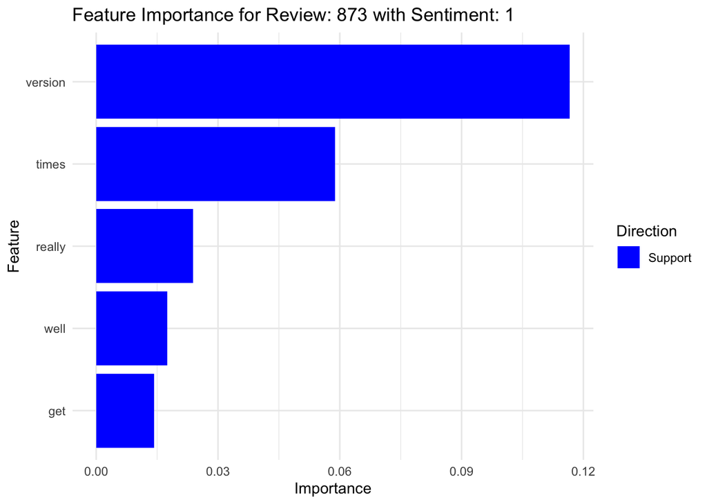

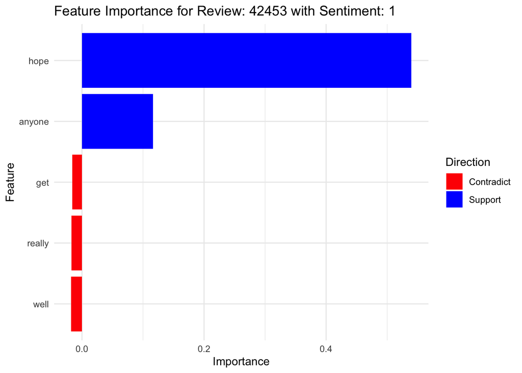

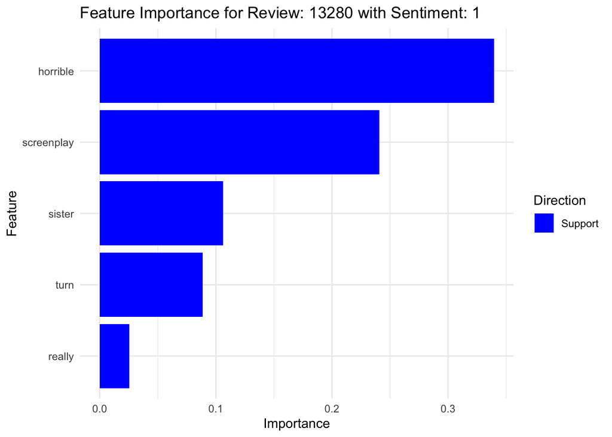

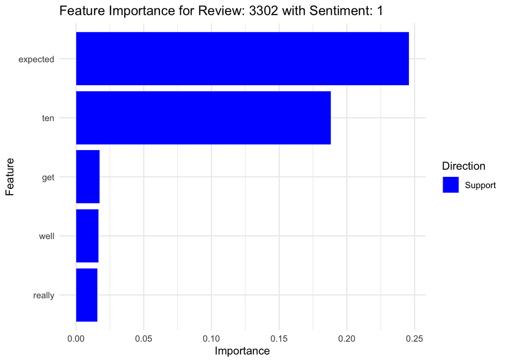

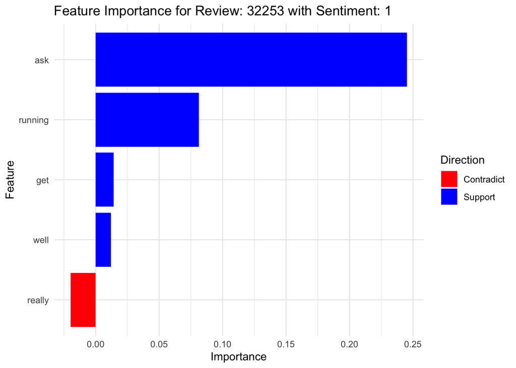

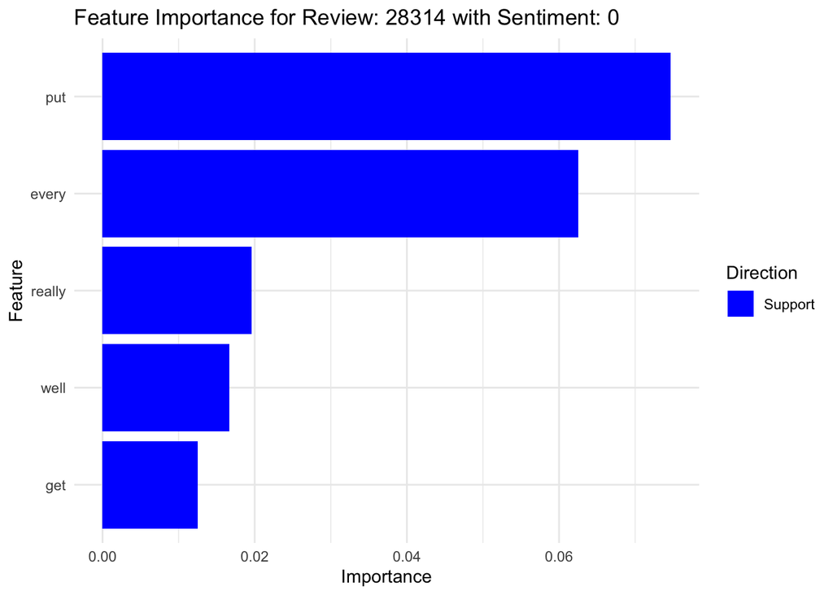

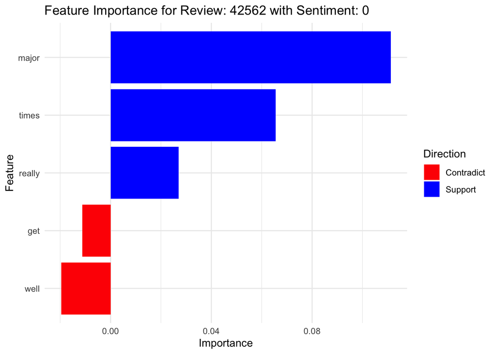

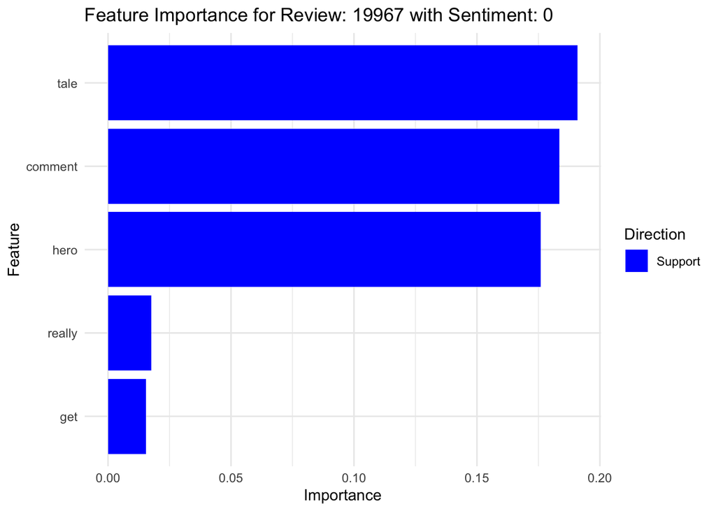

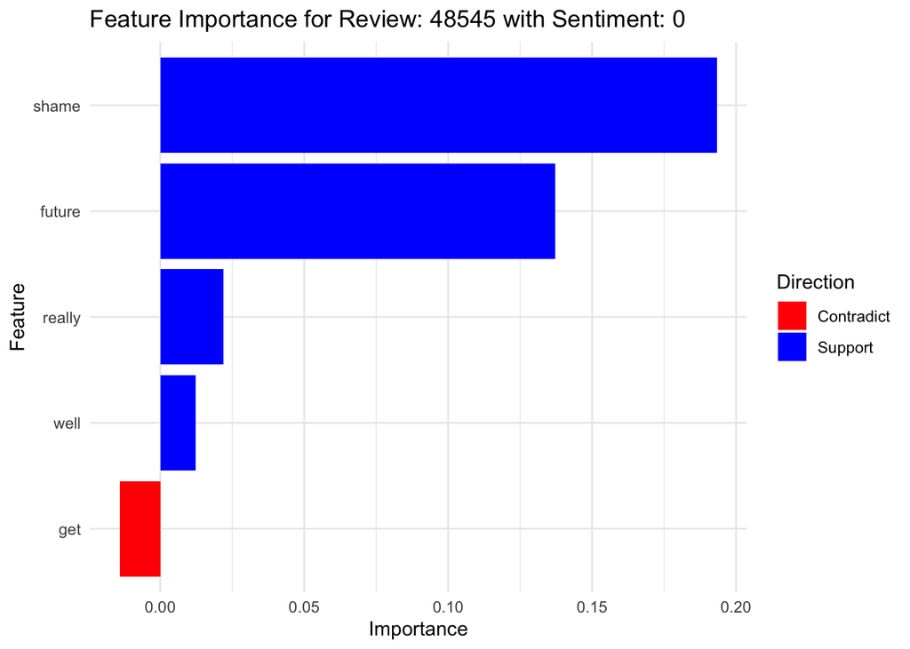

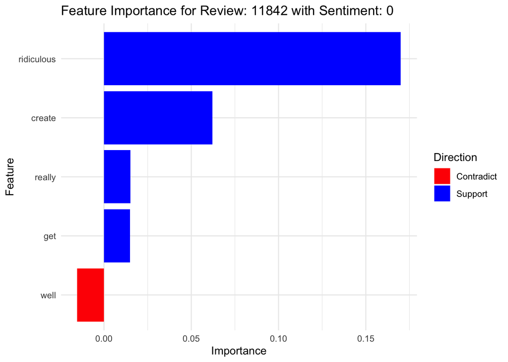

```r
# 2024-11-30, Wm. Jeptha Davenport (wjd4@illinois.edu)
# UIUC MCS Fall 2024 CS 598, Dr. Feng Liang
# PSL Project 3:  Movie Review Sentiment Analysis

# Load required libraries, quietly
suppressPackageStartupMessages({
library(dplyr)
library(tidyr)
library(stringr)
library(SnowballC)
library(readr)
library(tm)
library(caret)
library(purrr)
library(tokenizers)
library(lime)
library(ggplot2)
})

# Load trained logistic regression model from GitHub
url <- "https://raw.githubusercontent.com/wjdavenport/psl_project_sentiment_analysis/main/final_glmnet_model.rds"
download.file(url, destfile = "final_glmnet_model.rds", method = "curl")
loaded_model <- readRDS("final_glmnet_model.rds")

# Load the test data and labels
test_data <- read.csv('test.csv')
test_labels <- read.csv('test_y.csv')

# Ensure both test_data and test_labels contain the 'id' column and have no duplicate IDs
if (!'id' %in% colnames(test_data) || !'id' %in% colnames(test_labels)) {
  stop("Both test_data and test_labels must contain the 'id' column.")
}
if (anyDuplicated(test_data$id) > 0 || anyDuplicated(test_labels$id) > 0) {
  stop("Duplicate IDs found in test_data or test_labels. Ensure unique IDs before merging.")
}

# Merge the test data with the labels and ensure 'id' is retained
test_data <- merge(test_data, test_labels, by = "id", all = TRUE)

# Preprocess text data for interpretability
tidy_text <- function(text_column) {
  custom_stopwords <- c(stopwords("en"), "movie", "film", "character", "story", "john", "george", "i", "me", "my", "myself", "a", "an", "and", "the", "richard", "tim")  # Define custom stopwords to better fit the domain
  text_column %>%
    str_to_lower() %>%            # Convert text to lowercase
    removePunctuation() %>%       # Remove punctuation
    removeNumbers() %>%           # Remove numbers
    tm::removeWords(custom_stopwords) %>%  # Remove custom stopwords
    wordStem(language = "en")     # Perform word stemming
}

# Preprocess the test data
if (!'review' %in% colnames(test_data)) {
  stop("The 'review' column is missing in the test_data. Ensure the column exists before preprocessing.")
}

tidy_test_data <- test_data %>%
  drop_na() %>%  # Remove rows with NA values
  mutate(review = tidy_text(review))  # Apply text preprocessing to review column

# Create a Corpus and Document-Term Matrix (DTM) with limited features
corpus <- VCorpus(VectorSource(tidy_test_data$review))
dtm <- DocumentTermMatrix(corpus, control = list(weighting = weightTfIdf))

# Reduce dimensionality by removing sparse terms (e.g., keep terms that appear in at least 2% of the documents)
dtm <- removeSparseTerms(dtm, sparse = 0.98)

# Limit the number of features to the top 1000 terms
dtm <- dtm[, 1:min(1000, ncol(dtm))]

# Convert the reduced DTM to a data frame
tfidf_matrix <- as.data.frame(as.matrix(dtm))
tfidf_matrix$id <- tidy_test_data$id  # Add the ID column back for reference
tfidf_matrix$sentiment <- tidy_test_data$sentiment  # Add sentiment column for filtering

# Replace any NA values with 0 to avoid errors during prediction
tfidf_matrix[is.na(tfidf_matrix)] <- 0

# Remove columns with zero variance
tfidf_matrix <- tfidf_matrix[, sapply(tfidf_matrix, function(col) length(unique(col)) > 1)]

# Ensure tfidf_matrix has exactly 1536 features by adding missing columns with zeros
required_features <- 1536
current_features <- ncol(tfidf_matrix) - 2  # Subtracting id and sentiment
if (current_features < required_features) {
  missing_features <- required_features - current_features
  for (i in 1:missing_features) {
    tfidf_matrix[[paste0("V_missing_", i)]] <- 0
  }
}

# Save the processed tfidf_matrix for future use
write.csv(tfidf_matrix, "processed_tfidf_matrix.csv", row.names = FALSE)

# Select 5 positive and 5 negative reviews randomly
set.seed(1034)  # Set seed for reproducibility
positive_reviews <- tfidf_matrix %>% filter(sentiment == 1) %>% sample_n(5)
negative_reviews <- tfidf_matrix %>% filter(sentiment == 0) %>% sample_n(5)
selected_reviews <- bind_rows(positive_reviews, negative_reviews)

# Use lime for interpretability analysis
options(warn = -1)  # Suppress warnings globally
suppressWarnings({
  explainer <- lime::lime(
    x = tfidf_matrix %>% select(-id, -sentiment),
    model = loaded_model
  )
})

# Define a custom predict function for glmnet model
predict_model.glmnet <- function(model, newdata, type = "response", ...) {
  type <- "response"  # Force response type to ensure compatibility with lime
  as.data.frame(predict(model, newx = as.matrix(newdata), type = type))
}

# Define a custom model_type function for glmnet
model_type.glmnet <- function(x, ...) {
  "classification"
}

# Analyze each selected review with lime
selected_reviews$lime_analysis <- lapply(seq_len(nrow(selected_reviews)), function(i) {
  row_data <- selected_reviews[i, ] %>% select(-id, -sentiment)
  explanation <- suppressWarnings(lime::explain(
    x = row_data,
    explainer = explainer,
    n_labels = 1,
    n_features = 5
  ))
  explanation
})

# Suppress additional warnings during feature importance calculation
options(warn = -1)

# Plot the lime analysis for each review
for (i in seq_len(nrow(selected_reviews))) {
  review_id <- selected_reviews$id[i]
  explanation <- selected_reviews$lime_analysis[[i]]

  # Ensure the importance column exists, adjust if needed
  if (!"importance" %in% colnames(explanation)) {
    if ("feature_weight" %in% colnames(explanation)) {
      explanation$importance <- explanation$feature_weight  # Adjust the column name if different
    } else {
      cat(paste("\nReview ID:", review_id, " - No importance information available\n"))
      next
    }
  }

  # Instead of printing the full explanation, provide a summary
  # cat(paste("\nReview ID:", review_id, " - Summary of LIME Analysis\n"))
  # cat("Number of features analyzed:", nrow(explanation), "\n")
  # cat("Top 5 features contributing to prediction:\n")
  # print(head(explanation %>% arrange(desc(abs(importance))), 5))

  # Replace NA values in importance
  explanation <- explanation %>%
    mutate(importance = ifelse(is.na(importance), 0, importance))

  # Generate feature importance plot
  if ("importance" %in% colnames(explanation)) {
    p <- suppressWarnings(ggplot(explanation, aes(x = reorder(feature, importance), y = importance, fill = as.factor(sign(importance)))) +
      geom_bar(stat = "identity") +
      coord_flip() +
      labs(
        title = paste("Feature Importance for Review:", review_id, "with Sentiment:", selected_reviews$sentiment[i]),
        x = "Feature",
        y = "Importance",
        fill = "Direction"
      ) +
      scale_fill_manual(values = c("-1" = "red", "1" = "blue"), labels = c("-1" = "Contradict", "1" = "Support")) +
      theme_minimal())

    print(p)
  }
}
```

```r
# Suppress warnings related to insufficient variance in variables and other specific warnings
# suppressWarnings({
#   selected_reviews %>%
#     select(id, lime_analysis) %>%
#     print()
# })

# Restore warning options to default
options(warn = 0)
```

The resulting embedding matrix exceeds 25GB and so was not uploaded to GitHub, but could be compressed if needed.

Team Member:  
Name: Jeptha Davenport, netID: wjd4, Program: MCS-Online, I (Jeptha Davenport) contributed the code for this assignment.